# MA20226 Coursework

William Dennis

19/11/2020

### Question 1

*Suppose we have an i.i.d. sample of size n = 15 from an unknown continuous distribution. What is the critical region for a size $α=0.05$ test of the hypotheses in Equation (1) with $m_0=0$ based on the test statistic in Equation (2)?*

For $m$ to be the median of a set $x$, half of the values in $x$ must be above $m$ and half below $m$. This leads to us being able to describe each value in the test statistic as a Bernoulli distribution where $p=0.5$, with True, $t_i=1$ meaning that $x_i$ is above $m$ and False, $t_i=0$ meaning below. Thus from the question we can derive the equation where $m_c$ is the critical value and we also see that T is a binomial distribution.
$$P(T \geq i) \leq 0.05 \quad \textrm{and} \quad T \sim Bin(n = 15,p = \frac{1}{2})\quad \textrm{such that} \quad x_i = m_c$$
and then deduce
$$P(T \geq i) \leq 0.05 \quad = \quad P(T=i) + P(T=i+1)+ \quad ... \quad +P(T=15) \leq 0.05\\$$
$$=\quad\binom{15}{i} \left( \frac{1}{2} \right)^{15} + \binom{15}{i+1} \left( \frac{1}{2} \right)^{15}+\quad ... \quad +\binom{15}{15} \left( \frac{1}{2} \right)^{15}$$

$$=\quad\left( \frac{1}{2} \right)^{15}\left( \binom{15}{i}+\binom{15}{i+1}+\quad...\quad+\binom{15}{15}\right) \leq 0.05$$
To find the critical value $m$ we can use a R Script to find this.

```
##    Probability T>=i Less than 0.05?
## 0      1.000000e+00               0
## 1      9.999695e-01               0
## 2      9.995117e-01               0
## 3      9.963074e-01               0
## 4      9.824219e-01               0
## 5      9.407654e-01               0
## 6      8.491211e-01               0
## 7      6.963806e-01               0
## 8      5.000000e-01               0
## 9      3.036194e-01               0
## 10     1.508789e-01               0
## 11     5.923462e-02               0
## 12     1.757812e-02               1
## 13     3.692627e-03               1
## 14     4.882812e-04               1
## 15     3.051758e-05               1
```

As we can see from this table, the critical value $m_c$ is the 12th value in $x$ (where $x$ is ordered in ascending order) as it is the smallest value in $x$ that falls in the critical region of size $\alpha = 0.05$. Therefore the critical region is all values of $m \geq x_{12}$.

### Question 2

*Consider the following two data sets (which differ only in the first and last values)*

```r
set_1 = c(-1.4,2.8,3,0.8,1.5,2.2,-2.5,2,1.8,3.5,2.5,0.1,-3.3,3.6,1.4)
set_2 = c(-14,2.8,3,0.8,1.5,2.2,-2.5,2,1.8,3.5,2.5,0.1,-3.3,3.6,14)
```

*Carry out the Sign-Test with $m_0=0$ and the t-test with $μ_0=0$ on each data set using $α=0.05$. Comment on any similarities or differences between the two testing procedures. For this question, you may not use the functions introduced next.*

The hypothesis for the Sign-Test is a follows
$$H_0 \ : \ m=m_0 \quad \textrm{versus} \quad H_1 \ : \ m>m_0$$
To accept $H_0$ the number of values greater than $m=0$ must be less than 12 as shown from part 1.

```r
var1 = sum(set_1 > 0) #calculates the total number of values greater than zero
var2 = sum(set_2 > 0)
print(c(var1<=12,var2<=12))
```

```
## [1] TRUE TRUE
```

As we can see from these results we reject the null hypotheses for data set 1 and data set 2 as they both have 12 values greater than the mean.

The hypotheses for the T-Test is as follows

$$H_0 \ : \ μ=μ_0 \quad \textrm{versus} \quad H_1 \ : \ μ>μ_0$$
To carry out this test we reject the null hypotheses if this statement is true
$$\bar{x} \ \geq \ μ_0 + t_{1-α,n-1} \frac{s}{ \sqrt{n}} \implies \bar{x} \ \geq \ t_{1-α,n-1} \frac{s}{ \sqrt{n}} \tag{*}$$

$$t_{1-α,n-1} \quad = \quad t_{1-0.05,15-1} \quad = \quad t_{0.95,14} \quad = \quad 1.761$$
We calculate the T-values with the following R code

```r
mean1 = mean(set_1)
mean2 = mean(set_2)
var1 = 1.761 * sd(set_1) / sqrt(length(set_1)) #equation *
var2 = 1.761 * sd(set_2) / sqrt(length(set_2))

print(c(mean1 >= var1,mean2 >= var2))
```

```
## [1]  TRUE FALSE
```

We can then see that we reject the null hypotheses for data set 1 and accept the null hypotheses for data set 2.

### Question 3

```r
load(url('http://people.bath.ac.uk/trs35/tests_code.R'))
```

*Perform a simulation study to confirm that the Sign-Test (as coded in the function above) yields a test with the correct significance level using $nSim=10,000$ simulations of samples of size $n=100$ from a $N(μ,1)$ distribution with $α=0.05$.*

```r
set.seed(0)
nSim = 10000
n = 100
arr = array(0,dim=nSim)

for (i in 1:nSim){
  var = rnorm(n,mean = 0,sd = 1)#generates a sample from the normal distribution
  arr[i] = sign.test(var) #the default values are correct
}
print(sum(arr)/length(arr))
```

```
## [1] 0.0433
```

We can see that the significance level is less then 0.05 so we can confirm that it yields the correct significant level.

### Question 4

*Perform a simulation study to compare the power of the Sign-Test and the t-test using $nSim=1,000$ simulations of samples of size $n=25$ from a $N(μ,1)$ distribution. Plot the power of each test as a function of $μ$ in the interval (0, 2).*

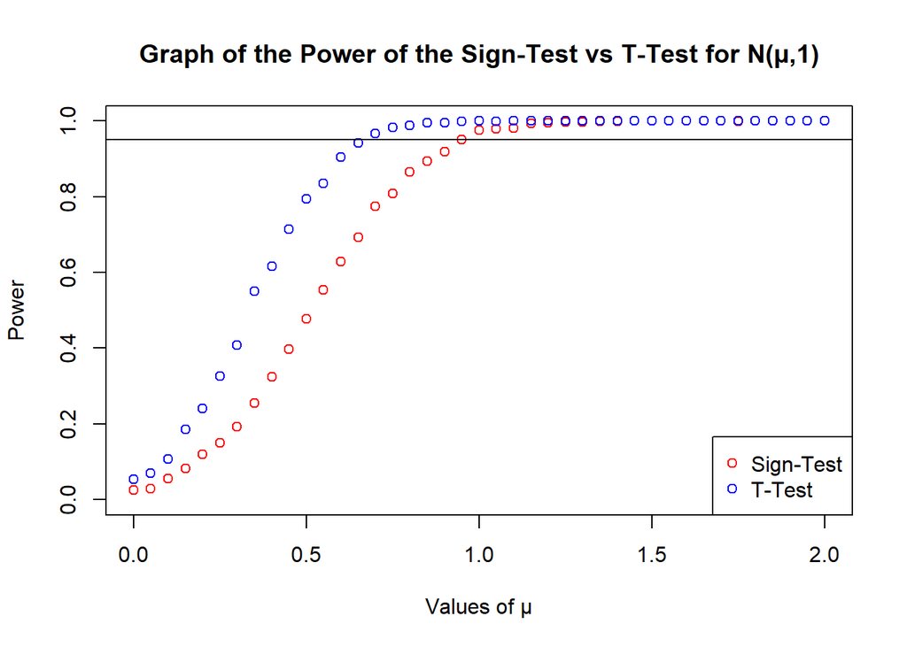

```r
set.seed(0)
nSim = 1000
n = 25
mew_arr = seq(0,2,0.05) #generates array of mew values

arr = array(0,dim=c(2,length(mew_arr)))

for (i in 1:length(mew_arr)){

  arr1 = array(0,dim=nSim)
  arr2 = array(0,dim=nSim)
  for (j in 1:nSim){
    var = rnorm(n, mean = mew_arr[i], sd = 1) #generates a sample from the normal distribution
    arr1[j] = sign.test(x = var)
    arr2[j] = myt.test(x = var)

  arr[1,i] =1 - sum(arr1) / length(arr1) #this is the probability of type 2 error for Sign-Test
  arr[2,i] =1 - sum(arr2) / length(arr2) #this is the probability of type 2 error for T-Test

  }
}

plot(mew_arr,1-arr[1,],main = 'Graph of the Power of the Sign-Test vs T-Test for N(μ,1)',xlab = 'Values of μ', ylab = 'Power',ylim = c(0,1),col='red')
points(mew_arr,1-arr[2,],col='blue')
abline(h=0.95)
legend('bottomright',legend=c('Sign-Test','T-Test'),col=c('red','blue'),pch=1)
```

### Question 5

*Perform a simulation study to compare the power of the Sign-Test and the t-test using $nSim=1,000$ simulations of samples of size $n=25$ from a Cauchy distribution with location parameter $m$ and scale parameter 1. You will need to consult the help file ?rcauchy. Plot the power of each test as a function of $m$ in the interval (0, 2).*

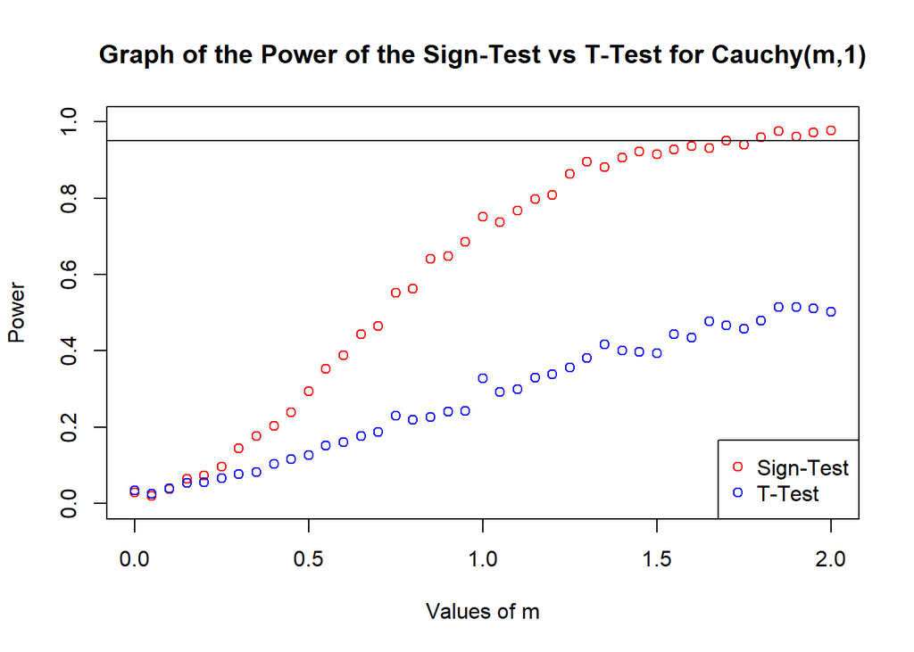

```r
set.seed(0)
nSim = 1000
n = 25
m_arr = seq(0,2,0.05) #generates array of m values

arr = array(0,dim=c(2,length(m_arr)))

for (i in 1:length(m_arr)){

  arr1 = array(0,dim=nSim)
  arr2 = array(0,dim=nSim)
  for (j in 1:nSim){
    var = rcauchy(n, location = m_arr[i], scale = 1) #generates a sample from the cauchy distribution
    arr1[j] = sign.test(x = var)
    arr2[j] = myt.test(x = var)

  arr[1,i] =1 - sum(arr1) / length(arr1) #this is the probability of type 2 error for Sign-Test
  arr[2,i] =1 - sum(arr2) / length(arr2) #this is the probability of type 2 error for T-Test

  }
}
plot(m_arr,1-arr[1,],main = 'Graph of the Power of the Sign-Test vs T-Test for Cauchy(m,1)',xlab = 'Values of m', ylab = 'Power',ylim = c(0,1),col='red')
points(m_arr,1-arr[2,],col='blue')
abline(h=0.95)
legend('bottomright',legend=c('Sign-Test','T-Test'),col=c('red','blue'),pch=1)
```

### Question 6

*Based on your simulation studies in Question 4 and 5, what conclusions do you draw about the relative merits of the two testing procedures?*

To measure the merit of each test I will be commenting on its effectiveness when the power is greater then 0.95 as this means that the test will detect a deviation from the null hypotheses, given the deviation exists, 95% of the time. For the normal distribution we can see that the T-Test has a higher power than the Sign-Test over all values, thus meaning it is a better test. We can also say that the T-Test it is effective on values of μ greater than 0.7 and the Sign-Test is effective on values of μ greater than 1. For the cauchy distribution we can see that the Sign-Test has a significantly higher power than the T-Test as m increases, indicating it is a better test. We can also say that the Sign-Test is effective on values of m greater than 1.75 and the T-Test never reaches a power of 0.95 so it is not effective over any value between 0 and 2.

### Question 7

*Write a function that takes in a vector of data x and a significance level α and returns a confidence interval for m based on inverting the Sign-Test. You will need to use the alternative = “two.sided” option in the sign.test function.*

The two sided Sign-Test is as such:

$$\left\{
\begin{array}{ll}
1 & \mbox{if } \quad P(T \geq m) \leq \frac{\alpha}{2} \ or \ P(T \leq m) \leq \frac{\alpha}{2} \\
0 & \mbox{if } \quad else
\end{array}
\right.$$

From this we can define the two confidence intervals where $x$ is an ordered list in ascending order:

$$C_1 \leq m < C_2$$

$$C_1 = x_i \textrm{ where } i\textrm{ is the largest value of } i \textrm{ such that }P(T \leq i) \leq \frac{\alpha}{2}$$

$$C_2 = x_{j+1} \textrm{ where } j\textrm{ is the largest value of } j \textrm{ such that }P(T \geq j) \leq \frac{\alpha}{2}$$
The upper bound $C_2$ is non-inclusive and equivalent to the ($j+1$)th value due to the following. For a number $x_n\in x$ to be accepted as the median by the Sign-Test, all values in the bounds $[x_n,x_{n+1})$ are also accepted. This is due to the indicator function in the test statistic being non inclusive of the median, such that:

$$1_{(m,\infty)}(m)=0 \implies sign.test(x,x_n) = sign.test(x,a) \quad \forall a\in[x_n,x_{n+1})$$
Therefore showing that we must add 1 to the j value to show that the median could also be values greater than the highest accepted value in x ($x_j$) but non-inclusive of $x_{j+1}$

```r
conf_int = function(x,alpha){
  x = sort(x) # x must be sorted
  output = array(dim=length(x))
  for (i in 1:length(x)){
    value = x[i]
    output[i] = sign.test(x,m=value,alpha = alpha, alternative='two.sided')
  }
  zeros = which(output %in% 0) # locate the values that are accepted
  lower_index = zeros[1] #location of the lower bound in x
  upper_index = tail(zeros,n=1) + 1 #location of the upper bound in x

  return (c(x[lower_index],x[upper_index]))
}
```

### Question 8

```r
var = conf_int(set_1,0.1)
print(sprintf('[%f,%f)',var[1],var[2]))
```

```
## [1] "[0.100000,2.800000)"
```

We can see that the function returns the interval $0.1 \leq m < 2.8$ and we can verify these results that 0.1 is inclusive and 2.8 is non-inclusive as shown in the graph below where the vertical line represent the bounds.

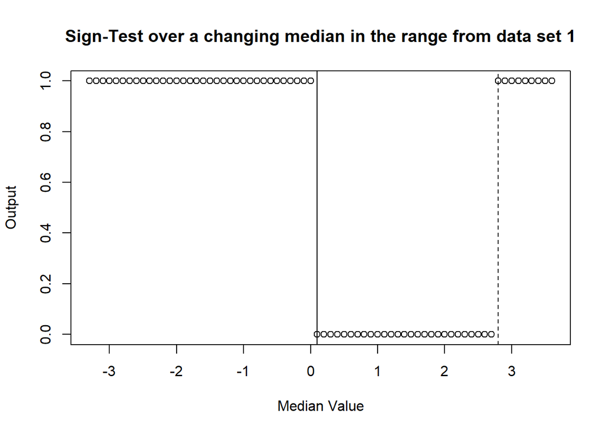